fastpages

# Machine Learning

Aug 30, 2020 • 30 min read

# Table of Contents

## Business Understanding

Dieser Schritt im CRISP-DM Zyklus läuft in der Regel ohne Technische Unterstützung ab. Hier geht es vorrangig darum, die Domäne in der wir uns bewegen zu verstehen. Das klingt einfach, ist es aber in der Regel nicht. Beim Kick-Off eines ML Projekts klingt vieles noch wenig vertraut und muss erst hinterfragt werden. Hier ein paar Fragen...

- Was macht das Unternehmen; womit verdient es sein Geld?
- Was wird mit dem aktuellen ML Projekt (wirklich) bezweckt?
- Wer unterstützt das Projekt (nicht)?
- Woher kommen die Daten, mit denen wir arbeiten sollen?
- Wer gewährt uns Zugriff zu welchen Daten?
- Warum sehen die Daten so aus, wie sie eben aussehen und nicht anders?
- Welche Features können wir nutzen versus Welche Features würden wir benötigen?
- Welche Möglichkeiten haben wir, unsere Daten zu erweitern?

## Data Loading

Natürlich beginnen wir unseren Machine Learning Prozess mit dem Laden der Daten. Hier verwenden wir `pandas`. Zum einen bietet Pandas eine Menge an Methoden, die uns beim Laden und Selektieren der Daten helfen; zum anderen aber bietet uns `pandas` auch einigen Support, bei der Vorverarbeitung der Daten.

```python
import pandas as pd

data = pd.read_csv("../data/housing.csv")
bikesharing_data = pd.read_csv("../data/Bikesharing.csv", index_col=0)
```

```python
data.median_income.mean()
```

```
3.8706710029069766
```

```python
#other method
bikesharing_data = bikesharing_data.fillna(bikesharing_data["windspeed"].median())
```

```python
data.fillna(data.median_income.mean())
```

|  | longitude | latitude | housing_median_age | total_rooms | total_bedrooms | population | households | median_income | median_house_value | ocean_proximity |
| --- | --- | --- | --- | --- | --- | --- | --- | --- | --- | --- |
| 0 | -122.23 | 37.88 | 41.0 | 880.0 | 129.0 | 322.0 | 126.0 | 8.3252 | 452600.0 | NEAR BAY |
| 1 | -122.22 | 37.86 | 21.0 | 7099.0 | 1106.0 | 2401.0 | 1138.0 | 8.3014 | 358500.0 | NEAR BAY |
| 2 | -122.24 | 37.85 | 52.0 | 1467.0 | 190.0 | 496.0 | 177.0 | 7.2574 | 352100.0 | NEAR BAY |
| 3 | -122.25 | 37.85 | 52.0 | 1274.0 | 235.0 | 558.0 | 219.0 | 5.6431 | 341300.0 | NEAR BAY |
| 4 | -122.25 | 37.85 | 52.0 | 1627.0 | 280.0 | 565.0 | 259.0 | 3.8462 | 342200.0 | NEAR BAY |
| 5 | -122.25 | 37.85 | 52.0 | 919.0 | 213.0 | 413.0 | 193.0 | 4.0368 | 269700.0 | NEAR BAY |
| 6 | -122.25 | 37.84 | 52.0 | 2535.0 | 489.0 | 1094.0 | 514.0 | 3.6591 | 299200.0 | NEAR BAY |
| 7 | -122.25 | 37.84 | 52.0 | 3104.0 | 687.0 | 1157.0 | 647.0 | 3.1200 | 241400.0 | NEAR BAY |
| 8 | -122.26 | 37.84 | 42.0 | 2555.0 | 665.0 | 1206.0 | 595.0 | 2.0804 | 226700.0 | NEAR BAY |
| 9 | -122.25 | 37.84 | 52.0 | 3549.0 | 707.0 | 1551.0 | 714.0 | 3.6912 | 261100.0 | NEAR BAY |
| 10 | -122.26 | 37.85 | 52.0 | 2202.0 | 434.0 | 910.0 | 402.0 | 3.2031 | 281500.0 | NEAR BAY |
| 11 | -122.26 | 37.85 | 52.0 | 3503.0 | 752.0 | 1504.0 | 734.0 | 3.2705 | 241800.0 | NEAR BAY |
| 12 | -122.26 | 37.85 | 52.0 | 2491.0 | 474.0 | 1098.0 | 468.0 | 3.0750 | 213500.0 | NEAR BAY |
| 13 | -122.26 | 37.84 | 52.0 | 696.0 | 191.0 | 345.0 | 174.0 | 2.6736 | 191300.0 | NEAR BAY |
| 14 | -122.26 | 37.85 | 52.0 | 2643.0 | 626.0 | 1212.0 | 620.0 | 1.9167 | 159200.0 | NEAR BAY |
| 15 | -122.26 | 37.85 | 50.0 | 1120.0 | 283.0 | 697.0 | 264.0 | 2.1250 | 140000.0 | NEAR BAY |
| 16 | -122.27 | 37.85 | 52.0 | 1966.0 | 347.0 | 793.0 | 331.0 | 2.7750 | 152500.0 | NEAR BAY |
| 17 | -122.27 | 37.85 | 52.0 | 1228.0 | 293.0 | 648.0 | 303.0 | 2.1202 | 155500.0 | NEAR BAY |
| 18 | -122.26 | 37.84 | 50.0 | 2239.0 | 455.0 | 990.0 | 419.0 | 1.9911 | 158700.0 | NEAR BAY |
| 19 | -122.27 | 37.84 | 52.0 | 1503.0 | 298.0 | 690.0 | 275.0 | 2.6033 | 162900.0 | NEAR BAY |
| 20 | -122.27 | 37.85 | 40.0 | 751.0 | 184.0 | 409.0 | 166.0 | 1.3578 | 147500.0 | NEAR BAY |
| 21 | -122.27 | 37.85 | 42.0 | 1639.0 | 367.0 | 929.0 | 366.0 | 1.7135 | 159800.0 | NEAR BAY |
| 22 | -122.27 | 37.84 | 52.0 | 2436.0 | 541.0 | 1015.0 | 478.0 | 1.7250 | 113900.0 | NEAR BAY |
| 23 | -122.27 | 37.84 | 52.0 | 1688.0 | 337.0 | 853.0 | 325.0 | 2.1806 | 99700.0 | NEAR BAY |
| 24 | -122.27 | 37.84 | 52.0 | 2224.0 | 437.0 | 1006.0 | 422.0 | 2.6000 | 132600.0 | NEAR BAY |
| 25 | -122.28 | 37.85 | 41.0 | 535.0 | 123.0 | 317.0 | 119.0 | 2.4038 | 107500.0 | NEAR BAY |
| 26 | -122.28 | 37.85 | 49.0 | 1130.0 | 244.0 | 607.0 | 239.0 | 2.4597 | 93800.0 | NEAR BAY |
| 27 | -122.28 | 37.85 | 52.0 | 1898.0 | 421.0 | 1102.0 | 397.0 | 1.8080 | 105500.0 | NEAR BAY |
| 28 | -122.28 | 37.84 | 50.0 | 2082.0 | 492.0 | 1131.0 | 473.0 | 1.6424 | 108900.0 | NEAR BAY |
| 29 | -122.28 | 37.84 | 52.0 | 729.0 | 160.0 | 395.0 | 155.0 | 1.6875 | 132000.0 | NEAR BAY |
| ... | ... | ... | ... | ... | ... | ... | ... | ... | ... | ... |
| 20610 | -121.56 | 39.10 | 28.0 | 2130.0 | 484.0 | 1195.0 | 439.0 | 1.3631 | 45500.0 | INLAND |
| 20611 | -121.55 | 39.10 | 27.0 | 1783.0 | 441.0 | 1163.0 | 409.0 | 1.2857 | 47000.0 | INLAND |
| 20612 | -121.56 | 39.08 | 26.0 | 1377.0 | 289.0 | 761.0 | 267.0 | 1.4934 | 48300.0 | INLAND |
| 20613 | -121.55 | 39.09 | 31.0 | 1728.0 | 365.0 | 1167.0 | 384.0 | 1.4958 | 53400.0 | INLAND |
| 20614 | -121.54 | 39.08 | 26.0 | 2276.0 | 460.0 | 1455.0 | 474.0 | 2.4695 | 58000.0 | INLAND |
| 20615 | -121.54 | 39.08 | 23.0 | 1076.0 | 216.0 | 724.0 | 197.0 | 2.3598 | 57500.0 | INLAND |
| 20616 | -121.53 | 39.08 | 15.0 | 1810.0 | 441.0 | 1157.0 | 375.0 | 2.0469 | 55100.0 | INLAND |
| 20617 | -121.53 | 39.06 | 20.0 | 561.0 | 109.0 | 308.0 | 114.0 | 3.3021 | 70800.0 | INLAND |
| 20618 | -121.55 | 39.06 | 25.0 | 1332.0 | 247.0 | 726.0 | 226.0 | 2.2500 | 63400.0 | INLAND |
| 20619 | -121.56 | 39.01 | 22.0 | 1891.0 | 340.0 | 1023.0 | 296.0 | 2.7303 | 99100.0 | INLAND |
| 20620 | -121.48 | 39.05 | 40.0 | 198.0 | 41.0 | 151.0 | 48.0 | 4.5625 | 100000.0 | INLAND |
| 20621 | -121.47 | 39.01 | 37.0 | 1244.0 | 247.0 | 484.0 | 157.0 | 2.3661 | 77500.0 | INLAND |
| 20622 | -121.44 | 39.00 | 20.0 | 755.0 | 147.0 | 457.0 | 157.0 | 2.4167 | 67000.0 | INLAND |
| 20623 | -121.37 | 39.03 | 32.0 | 1158.0 | 244.0 | 598.0 | 227.0 | 2.8235 | 65500.0 | INLAND |
| 20624 | -121.41 | 39.04 | 16.0 | 1698.0 | 300.0 | 731.0 | 291.0 | 3.0739 | 87200.0 | INLAND |
| 20625 | -121.52 | 39.12 | 37.0 | 102.0 | 17.0 | 29.0 | 14.0 | 4.1250 | 72000.0 | INLAND |
| 20626 | -121.43 | 39.18 | 36.0 | 1124.0 | 184.0 | 504.0 | 171.0 | 2.1667 | 93800.0 | INLAND |
| 20627 | -121.32 | 39.13 | 5.0 | 358.0 | 65.0 | 169.0 | 59.0 | 3.0000 | 162500.0 | INLAND |
| 20628 | -121.48 | 39.10 | 19.0 | 2043.0 | 421.0 | 1018.0 | 390.0 | 2.5952 | 92400.0 | INLAND |
| 20629 | -121.39 | 39.12 | 28.0 | 10035.0 | 1856.0 | 6912.0 | 1818.0 | 2.0943 | 108300.0 | INLAND |
| 20630 | -121.32 | 39.29 | 11.0 | 2640.0 | 505.0 | 1257.0 | 445.0 | 3.5673 | 112000.0 | INLAND |
| 20631 | -121.40 | 39.33 | 15.0 | 2655.0 | 493.0 | 1200.0 | 432.0 | 3.5179 | 107200.0 | INLAND |
| 20632 | -121.45 | 39.26 | 15.0 | 2319.0 | 416.0 | 1047.0 | 385.0 | 3.1250 | 115600.0 | INLAND |
| 20633 | -121.53 | 39.19 | 27.0 | 2080.0 | 412.0 | 1082.0 | 382.0 | 2.5495 | 98300.0 | INLAND |
| 20634 | -121.56 | 39.27 | 28.0 | 2332.0 | 395.0 | 1041.0 | 344.0 | 3.7125 | 116800.0 | INLAND |
| 20635 | -121.09 | 39.48 | 25.0 | 1665.0 | 374.0 | 845.0 | 330.0 | 1.5603 | 78100.0 | INLAND |
| 20636 | -121.21 | 39.49 | 18.0 | 697.0 | 150.0 | 356.0 | 114.0 | 2.5568 | 77100.0 | INLAND |
| 20637 | -121.22 | 39.43 | 17.0 | 2254.0 | 485.0 | 1007.0 | 433.0 | 1.7000 | 92300.0 | INLAND |
| 20638 | -121.32 | 39.43 | 18.0 | 1860.0 | 409.0 | 741.0 | 349.0 | 1.8672 | 84700.0 | INLAND |
| 20639 | -121.24 | 39.37 | 16.0 | 2785.0 | 616.0 | 1387.0 | 530.0 | 2.3886 | 89400.0 | INLAND |

20640 rows × 10 columns

## Data Wrangling

### GroupBy

```python
top_publishers = df.groupby('Publisher').size().sort_values(ascending=False).head(10).index.to_list()
for i in top_publishers:
    print(f'-) {i}')

df['Publisher'] = df['Publisher'].where(df['Publisher'].isin(top_publishers), 'other')
df.groupby('Publisher').size().sort_values(ascending=False)
```

```python
df_gr = df.groupby(['Year','Publisher']).sum()
df_gr = df_gr.drop(['Rank'], axis=1)
df_gr.head()

# change the shape of data frame from multiindex labels to column names
test = df_gr.unstack(level=-1)
test.columns = [' '.join(col).strip() for col in test.columns.values]
test.head()

# get the 30 publishers with the most rows of sales data
from collections import Counter
pub_count = Counter(df.Publisher)
res = pub_count.most_common(30)

# show as a bar plot
pub = pd.DataFrame([lis[1] for lis in res], [lis[0] for lis in res], columns=['Count'])
plt.bar(pub.index, pub.Count)
plt.xticks(rotation='vertical')
plt.title('Top 30 Publishers - Count of Data Points')
plt.show()

# create new table with Global_Sales, named by Publisher, as predictor and Year as Index
gs = pd.DataFrame(df[df.Publisher.isin(pub.index)].groupby(['Year','Publisher']).sum().Global_Sales)
gs = gs.unstack(level=-1)
gs.columns = gs.columns.get_level_values(1)
gs.head()


gs.isna().sum()
gs = gs.fillna(0)

# show sales data over time
plt.figure(figsize=[16,10])
plt.plot(gs)
plt.title('Global Sales of 30 Publishers with most data')
plt.legend(gs.columns)
```

### Filter Condition

```python
selected = df[df["Critic_Category"]>=80]
```

### Unique

```python
len(df.Publisher.unique())
```

## Data Understanding

```python
import seaborn as sns
from matplotlib import pyplot as plt
```

### Head, Describe, Info, ISNA, ANY

Hier haben wir einige der wichtigsten `pandas` methoden zusammengestellt, um sich einen schnellen Überblick über die Daten verschaffen zu können. Dazu gehören unter anderem...

- `head(n)`, um die ersten n Zeilen des Dataframes zu zeigen
- `describe()`, um eine deskriptive Statistik der nummerischen Spalten zu erhalten
- `info()` um Datentypinfos für alle Spalten zu bekommen
- `isna()` um Datenfelder auf `NaN`-Werte hin zu prüfen (meistens nur in Kombination mit `any()` sinnvoll)
- `any()` um Bool'sche Spalten über eine Prüfung verdichten (`True`, wenn zumindest ein `True`-Wert enthalten)

```python
data.head(3)
```

|  | longitude | latitude | housing_median_age | total_rooms | total_bedrooms | population | households | median_income | median_house_value | ocean_proximity |
| --- | --- | --- | --- | --- | --- | --- | --- | --- | --- | --- |
| 0 | -122.23 | 37.88 | 41.0 | 880.0 | 129.0 | 322.0 | 126.0 | 8.3252 | 452600.0 | NEAR BAY |
| 1 | -122.22 | 37.86 | 21.0 | 7099.0 | 1106.0 | 2401.0 | 1138.0 | 8.3014 | 358500.0 | NEAR BAY |
| 2 | -122.24 | 37.85 | 52.0 | 1467.0 | 190.0 | 496.0 | 177.0 | 7.2574 | 352100.0 | NEAR BAY |

```python
data.describe()
```

|  | longitude | latitude | housing_median_age | total_rooms | total_bedrooms | population | households | median_income | median_house_value |
| --- | --- | --- | --- | --- | --- | --- | --- | --- | --- |
| count | 20640.000000 | 20640.000000 | 20640.000000 | 20640.000000 | 20433.000000 | 20640.000000 | 20640.000000 | 20640.000000 | 20640.000000 |
| mean | -119.569704 | 35.631861 | 28.639486 | 2635.763081 | 537.870553 | 1425.476744 | 499.539680 | 3.870671 | 206855.816909 |
| std | 2.003532 | 2.135952 | 12.585558 | 2181.615252 | 421.385070 | 1132.462122 | 382.329753 | 1.899822 | 115395.615874 |
| min | -124.350000 | 32.540000 | 1.000000 | 2.000000 | 1.000000 | 3.000000 | 1.000000 | 0.499900 | 14999.000000 |
| 25% | -121.800000 | 33.930000 | 18.000000 | 1447.750000 | 296.000000 | 787.000000 | 280.000000 | 2.563400 | 119600.000000 |
| 50% | -118.490000 | 34.260000 | 29.000000 | 2127.000000 | 435.000000 | 1166.000000 | 409.000000 | 3.534800 | 179700.000000 |
| 75% | -118.010000 | 37.710000 | 37.000000 | 3148.000000 | 647.000000 | 1725.000000 | 605.000000 | 4.743250 | 264725.000000 |
| max | -114.310000 | 41.950000 | 52.000000 | 39320.000000 | 6445.000000 | 35682.000000 | 6082.000000 | 15.000100 | 500001.000000 |

```python
df.describe().transpose()
```

```python
data.info()
```

```
<class 'pandas.core.frame.DataFrame'>
RangeIndex: 20640 entries, 0 to 20639
Data columns (total 10 columns):
longitude             20640 non-null float64
latitude              20640 non-null float64
housing_median_age    20640 non-null float64
total_rooms           20640 non-null float64
total_bedrooms        20433 non-null float64
population            20640 non-null float64
households            20640 non-null float64
median_income         20640 non-null float64
median_house_value    20640 non-null float64
ocean_proximity       20640 non-null object
dtypes: float64(9), object(1)
memory usage: 1.6+ MB
```

```python
data.isna().any()
```

```
longitude             False
latitude              False
housing_median_age    False
total_rooms           False
total_bedrooms         True
population            False
households            False
median_income         False
median_house_value    False
ocean_proximity       False
dtype: bool
```

```python
data.corr()
```

|  | longitude | latitude | housing_median_age | total_rooms | total_bedrooms | population | households | median_income | median_house_value |
| --- | --- | --- | --- | --- | --- | --- | --- | --- | --- |
| longitude | 1.000000 | -0.924664 | -0.108197 | 0.044568 | 0.069608 | 0.099773 | 0.055310 | -0.015176 | -0.045967 |
| latitude | -0.924664 | 1.000000 | 0.011173 | -0.036100 | -0.066983 | -0.108785 | -0.071035 | -0.079809 | -0.144160 |
| housing_median_age | -0.108197 | 0.011173 | 1.000000 | -0.361262 | -0.320451 | -0.296244 | -0.302916 | -0.119034 | 0.105623 |
| total_rooms | 0.044568 | -0.036100 | -0.361262 | 1.000000 | 0.930380 | 0.857126 | 0.918484 | 0.198050 | 0.134153 |
| total_bedrooms | 0.069608 | -0.066983 | -0.320451 | 0.930380 | 1.000000 | 0.877747 | 0.979728 | -0.007723 | 0.049686 |
| population | 0.099773 | -0.108785 | -0.296244 | 0.857126 | 0.877747 | 1.000000 | 0.907222 | 0.004834 | -0.024650 |
| households | 0.055310 | -0.071035 | -0.302916 | 0.918484 | 0.979728 | 0.907222 | 1.000000 | 0.013033 | 0.065843 |
| median_income | -0.015176 | -0.079809 | -0.119034 | 0.198050 | -0.007723 | 0.004834 | 0.013033 | 1.000000 | 0.688075 |
| median_house_value | -0.045967 | -0.144160 | 0.105623 | 0.134153 | 0.049686 | -0.024650 | 0.065843 | 0.688075 | 1.000000 |

### Pairplot (Seaborn)

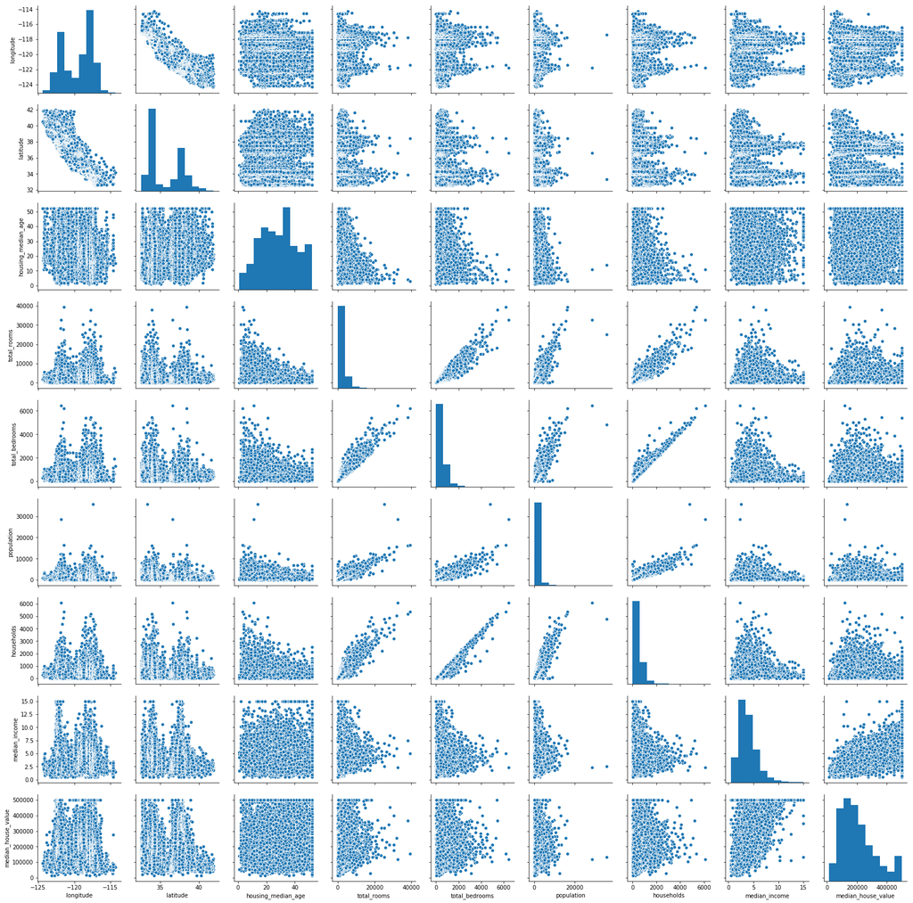

```python
sns.pairplot(data.select_dtypes(include=["number"]).dropna())
```

### Clustermap (seaborn)

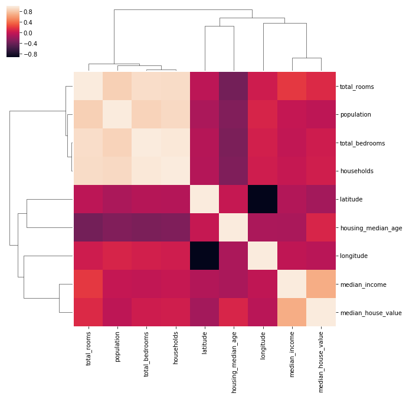

```python
sns.clustermap(data.select_dtypes(include=["number"]).dropna().corr())
```

### Histogram of all Variables

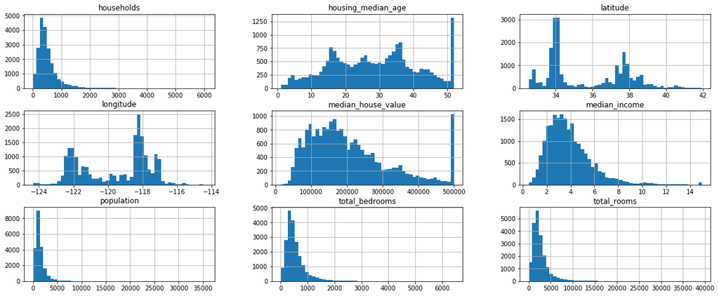

```python
data.hist(bins=50, figsize=(20,8))
plt.show()
```

### Histogram Single Variables

```python
titanic_data["age"].plot.hist()
```

```python
df.groupby('Developer').size().plot(kind='hist', bins=30, figsize=(10,10))
```

### RealMap Plot

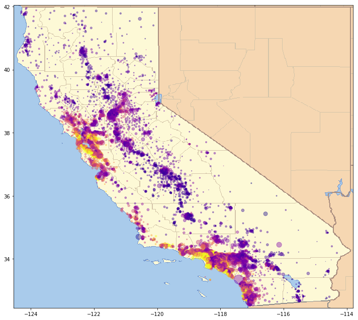

```python
import matplotlib.image as mpimg
import matplotlib.cm as cm

data_frame_plot = data[[
    'longitude',
    'population',
    'latitude',
    'median_house_value'
]]

plt.figure(figsize=(10,10))

plt.scatter(
    x=data_frame_plot.longitude,
    y=data_frame_plot.latitude,
    s=data_frame_plot.population/109,
    c=data_frame_plot.median_house_value,
    alpha=0.4,
    cmap='plasma',
    marker="o",
)

plt.imshow(
#    plt.imread('../img/california.png'),
    extent=[-124.55, -113.80, 32.45, 42.05],
    alpha=0.9
)

plt.tight_layout()
#plt.savefig("../img/california_analysis.png")
plt.show()
```

### Countplot (seaborn)

```python
sns.countplot(x="survived", data=titanic_data)

sns.countplot(x="survived", hue="sex", data=titanic_data)

sns.countplot(x="survived", hue="pclass", data=titanic_data)

plt.figure(figsize=(10,5))
sns.countplot(x="Genre", data=vgsales_data)
```

### HeatMap (seaborn)

```python
sns.heatmap(titanic_data.isnull(), yticklabels=False )
```

```python
corr=vgsales_data.corr()
corr = (corr)
plt.figure(figsize=(10,10))
ax = sns.heatmap(corr, cbar = True,  square = True, annot=True, fmt= '.2f',annot_kws=

{'size': 10},
            xticklabels=corr.columns.values,
            yticklabels=corr.columns.values)
ax.set_title('Heatmap of Correlation Matrix')
```

```python
corrMatrix = vgsales[numeric_features].corr()
sns.heatmap(corrMatrix, annot=True)
plt.show()
```

### Boxplot (Seaborn)

```python
sns.boxplot(x="pclass", y="age", data=titanic_data)
```

### Barplot (seaborn)

```python
sns.barplot(x="season", y="cnt", data=bikesharing_data)
```

```python
# Platform overview of the when it comes to genre
Genre = pd.crosstab(vgsales_data.Platform,vgsales_data.Genre)
GenreTotal = Genre.sum(axis=1).sort_values(ascending = False)
plt.figure(figsize=(10,10))
sns.barplot(x=GenreTotal.values,y=GenreTotal.index)
```

### Scatterplot(Seaborn)

```python
plt.scatter(x = "mnth", y = "cnt", data=bikesharing_data)
```

### Lineplot (seaborn)

```python
#Overview of the Global market sales from 1980 to 2020
plt.subplots(figsize=(14,6))
sns.lineplot(vgsales_data.index, y="NA_Sales", label="NA_Sales", color="red", data=vgsales_data)
sns.lineplot(vgsales_data.index, y="EU_Sales", label="EU_Sales",color="blue", data=vgsales_data)
sns.lineplot(vgsales_data.index, y="JP_Sales", label="JP_Sales",color="orange", data=vgsales_data)
sns.lineplot(vgsales_data.index, y="Other_Sales", label="Other_Sales",color="green", data=vgsales_data)
sns.lineplot(vgsales_data.index, y="Global_Sales",label="Global_Sales",color="violet", data=vgsales_data)
plt.ylabel("Sales")
plt.title("Video Games Sales")
plt.show()
```

## Überlegungen zu unseren Daten

**Woher kommen eigentlich unsere Daten?** Das ist eine banale aber wichtige Frage. Meistens werden uns unsere Daten von DomänenexpertInnen zusammengestellt und meistens folgen deren Überlegungen beim Zusammenstellen der Daten einem von zwei einfachen Prinzipen: (a) Welche Daten habe ich, und/oder (b) Welche Daten könnte der Data Scientist brauchen. Das übergebene Datenset enthält aber nicht immer jene Daten, die auch gute ML Ergebnisse bringen.

Das sind die Features, die wir bekommen haben...

- Längengrad (Ost-West-Lage)
- Breitengrad (Nord-Süd-Lage)
- Mittleres Alter in einem Zensus-Block
- N der Räume in einem Zensus-Block
- N Schlafzimmer in einem Zensus-Block
- N der Bewohner im Zensus-Block
- N Haushalte im Zensus-Block
- Mittleres Einkommen (in 10.000 USD)
- Mittlerer Hauswert (in USD)
- Entfernung zum Meer

Das sind die Features, die wir vielleicht brauchen...

- Nächste große Stadt
- Größe der nächsten Stadt
- N der Städte im Einzugsgebiet
- Entwicklung der nächsten, großen Stadt
- Zimmer pro EinwohnerIn im Einzugsgebiet
- Schlafzimmer pro EinwohnerIn im Einzugsgebiet
- Personendichte (Population/Haushalte)
- usw.

## Train Test Splitting

Dieser Schritt mag an dieser Stelle unpassend wirken, aber Nein! Wir spalten unsere Daten bewusst jetzt sofort in Trainings- und Testdaten auf. Wir tun das, weil wir alle weiteren Vorverarbeitungsschritte nur an unseren Trainings-Daten justieren wollen. Unsere Test-Daten legen wir zur Seite und greifen sie erst wieder an, wenn es um die Evaluierung unseres Modells geht.

Beim Splitting sind technisch gesehen sogar zwei Schritte erforderlich: Dabei sind zwei Schritte notwendig. Zum einen müssen wir unser Datenset in Input- und Output-Features spalten. Zum anderen sollten wir unsere Daten in ein Trainings- und ein Test-Datenset zerlegen.

```python
from sklearn.model_selection import train_test_split
```

```python
# trennen in input und output Features
input_feature_names = [
    'longitude',
    'latitude',
    'housing_median_age',
    'total_rooms',
    'total_bedrooms',
    'population',
    'households',
    'median_income',
    'ocean_proximity'
]

output_feature_names = ["median_house_value"]

# Datenset horizontal in input/output features splitten
X = data[input_feature_names]
y = data[output_feature_names]
```

```python
# trennen in nummerische und nicht-numerische Features
numeric_feature_names = list(X.select_dtypes(include=['number']).columns)
nonnumeric_feature_names = list(X.select_dtypes(exclude=['number']).columns)

# train/test Daten aufteilen
X_train, X_test, y_train, y_test = train_test_split(
    X,
    y,
    test_size=0.3,
    random_state=1239
)
```

```python
# Other method in selecting x and y variables
X = bikesharing_data.drop("cnt", axis=1)
y = bikesharing_data["cnt"]

X_train, X_test, y_train, y_test = train_test_split(X, y, test_size=0.2, random_state=1)
```

```python
# Other method , Defining Input and output features
X = socr_data.drop(["Weight(pounds)"], axis=1)
y = socr_data[["Weight(pounds)"]]

#Normalize features
scaler = MinMaxScaler()
X = scaler.fit_transform(X)
y = scaler.fit_transform(y)

#Train Test split
X_train, X_test, y_train, y_test = train_test_split(X, y, test_size=0.2, random_state=1)
```

## Data Preprocessing

Hier müssen wir wir uns mit vielen Dingen beschäftigen, was uns in der Regel 80% unserer Arbeitszeit kostet. Die wichtigsten Schritte sind:

- Bereinigen fehlender Werte
- Bereinigen nicht-nummerische Werte
- Bereinigung von Skalierungen

### Bereinigen fehlender Werte

Unser erster Schritt beim Bereinigen der Daten, ist das Bereinigen von fehlenden Werten. Wir prüfen dazu mit hilfe von `pandas`, wo solche Werte auftreten und wie zahlreich sie sind. Anschließend überlegen wir uns, was wir mit diesen Werten machen wollen. Hier sprechen wir unterhalb einige gängige Möglichkeiten an.

```python
data.isna().any()
```

```
longitude             False
latitude              False
housing_median_age    False
total_rooms           False
total_bedrooms         True
population            False
households            False
median_income         False
median_house_value    False
ocean_proximity       False
dtype: bool
```

```python
data.total_bedrooms.isna().sum()
```

```
207
```

Es scheint als gäbe es 207 fehlende Werte in der Spalte `total_bedrooms` unsers Datasets. Hier müssen wir Abhilfe schaffen, weil wir später, in der Analysephase, mit diesen Werten nicht weiterarbeiten können. Hier haben wir folgende Möglichkeiten:

- **Variante 1:** Füllen mit einem bestimmten Wert (z.B. 0)
- **Variante 2:** Füllen mit einem rechnerischen Wert (z.B. Arithmetisches Mittel [bei Ratioskalierten Merkmalen] oder Median [bei Ordinalen Merkmalen])
- **Variante 3:** Entfernen der betroffenen Datensätze
- **Variante 4:** Bei Zeitreihen: Approximation des Wertes im Zeitverlauf (z.B. Lineare Aproximation über die beiden angrenzenden Datenpunkte)

Variante 1 (füllen) und Variante 3 (entfernen) lassen sich sehr einfach mit Pandas umsetzen. Diese Varianten sind aber kritisch zu bewerten, weil sie dsa Datenbild entweder extrem verzerren oder uns wertvolle Daten kosten können.

```
# hier werden fehlende Werte z.B. mit 0 gefüllt
new_dataframe = old_dataframe.fillna(0)

# hier werden Zeilen mit fehlenden Werten gelöscht
new_dataframe = old_dataframe.dropna()
```

### Bereinigen nicht-nummerische Werte

Nicht-Numerische Spalten bereiten uns bei der weiteren Verarbeitung in der Regel Probleme. Darum überführen wir diese Spalten in ein nummerisches Format. Wir haben hier zwei unterschiedliche Optionen, die beide von `sklearn` unterstützt werden.

- **Variante 1** ist das Label-Encoding, bei dem jedem nicht-numerischen Wert ein numerischer Wert (0, 1, 2, 3 usw.) zugeordnet wird.
- **Variante 2** (und von uns präferiert) ist das One-Hot-Encoding, bei dem für jede Merkmalsausprägung eines kategorialen Attributs eine neue Spalte angelegt wird, die anschließend mit 0 oder 1 codiert wird - je nachdem, ob der Datensatz die Kategorie trägt, oder nicht.

**Label Encoding** von nicht-nummerischen, kategorialen Attributen mit `pandas` ist ähnlich einfach, wie das füllen oder entfernen von leeren Werten:

```
numeric, categories = data.ocean_proximity.factorize()
```

Alternativ kann hier natürlich mit `sklearn` gearbeitet werden. Dazu wird z.B. der Tranformer `LabelEncoder` verwendet. Der Vorteil: Dieser lässt sich vorwärts und rückwärts anwenden (also zum codieren und decodieren).

```
from sklearn.preprocessing import LabelEncoder

# neus Objekt der LabelEncoder-Klasse instanziieren
label_encoder = LabelEncoder()

# festlegen der Labels
label_encoder.fit(data.ocean_proximity)

# durchführen des Encodings
encoded_data = label_encoder.tranform(data.ocean_proximity)

# oder alternativ, beide Schritte auf einmal
encoded_data = label_encoder.fit_tranform(data.ocean_proximity)
```

```python
#Converting all variables into numeric.
from sklearn import model_selection, preprocessing
for c in vgsales_data.columns:
    if vgsales_data[c].dtype == 'object':
        lbl = preprocessing.LabelEncoder()
        lbl.fit(list(vgsales_data[c].values))
        vgsales_data[c] = lbl.transform(list(vgsales_data[c].values))
vgsales_data.head(3)
```

Aber halt! Im Maschinellen Lernen kann es beim Label-Encoding zu Problemen kommen. Warum? Wenn wir nicht aufpassen, wird unser encodetes Label als Ordinales Merkmal verarbeitet.

Das bedeutet Kategorie 3 ist besser (weil höher) als Kategorie 2, ist besser (weil höher) als Kategorie 1 usw.. Das ist aber leider vollkommen falsch. Unser Merkmal ist eigentlich nominal und repräsentiert keine interne Ordnung. Das sagt uns später nur leider niemand mehr, und wenn wir nicht aufpassen, wird es von unserem ML Algorithmus vollkommen falsch aufgenommen. Die Lösung lautet hier **One-Hot-Encoding**.

```
from sklearn.preprocessing import OneHotEncoder

# neus Objekt der OneHotEncoder-Klasse instanziieren
one_hot_encoder = OneHotEncoder()

# extrahieren der Werte des Dataframes als nd-array
data_to_encode = data.ocean_proximity.values

# umformen der Werte in eine Liste aus Einzellisten
data_to_encode = data_to_encode.reshape(-1,1)

# fitten und anwenden des encoders
# alternativ könnten auch die methoden fit() und transform()
# separat voneinander angewendet werden
encoded_data = one_hot_encoder.fit_tranform(data_to_encode)
```

### Bereinigung von Skalierungen

Features machen uns nicht nur dann Schwierigkeiten, wenn sie leere Werte enthalten. Auch die Wertebereiche einzelner Features können bei der Analyse Probleme bereiten. Unser Datenset enthält z.B. Features mit sehr hohen Werten und andere mit eher kleinen Werten. Features mit hohen Werten könnten bei der Modellierung einen höheren Stellenwert bekommen, als solche mit niedrigen Werten. Deshalb Skalieren wir unsere Features vor der Modellierung.

#### MinMaxScaler

**MinMaxscaler**: Arbeitet mit dem gesamten Wertebereich des Merkmals und ist deshalb anfällig für Ausreißer

$$s_i = \dfrac{x_i–min(x)}{max(x)–min(x)}$$

```
from sklearn.preprocessing import MinMaxScaler

# neus Objekt der MinMaxScaler-Klasse instanziieren
mima_scaler = MinMaxScaler()

# fitten und anwenden des encoders
# alternativ könnten auch die methoden fit() und transform()
# separat voneinander angewendet werden
mima_scaler.fit_transform(data[numeric_feature_names])
```

```
#Other method Normalize Data
X = bikesharing_data.drop("cnt", axis=1)
y = bikesharing_data[["cnt"]]

scaler = MinMaxScaler()
X = scaler.fit_transform(X)
y = scaler.fit_transform(y)
```

#### RobustScaler

**RobustScaler**: Arbeitet mit dem Interquartilsabstand des Merkmals und ist deshalb robust gegenüber Ausreißer

$$s_i = \dfrac{x_i–Q_1(x)}{Q_3(x)–Q_1(x)}$$

```
from sklearn.preprocessing import RobustScaler

# neus Objekt der RobustScaler-Klasse instanziieren
rob_scaler = RobustScaler()

# fitten und anwenden des encoders
# alternativ könnten auch die methoden fit() und transform()
# separat voneinander angewendet werden
rob_scaler.fit_transform(data[numeric_feature_names])
```

#### One-Hot Encoding

```
#Dummify categorical features
seasons = pd.get_dummies(bikesharing_data["season"], drop_first=True)
weekdays = pd.get_dummies(bikesharing_data["weekday"], drop_first=True)
weathersits = pd.get_dummies(bikesharing_data["weathersit"], drop_first=True)
workingday = pd.get_dummies(bikesharing_data["workingday"], drop_first=True)

#concatenate the new variables to the original dataset
bikesharing_data = pd.concat([bikesharing_data, seasons, weekdays, weathersits, workingday], axis=1)

# Drop unnecessary variables
bikesharing_data = bikesharing_data.drop(columns=["instant","dteday", "season","yr", "weekday","weathersit","workingday"])
bikesharing_data.head()
```

### Pipeline Verarbeitung

Wir werden im Lab unsere gesamte Vorverarbeitung mit Hilfe von **Pipelines** umsetzen. Das hat einige Vorteile:

1. Wir können die Schritte der Pipeline reproduzierbar auf Traings-, Test- und neue Daten anwenden.
2. Wir können die Schritte der Pipeline komfortabel rückwärts abwickln (z.B. um geschätzte Werte wieder zu skalieren.
3. Wir können das Pipelineobjekt einfach einfach handhaben und wiederverwenden.

```python
from sklearn.impute import SimpleImputer
from sklearn.preprocessing import OneHotEncoder, MinMaxScaler
from sklearn.pipeline import Pipeline, FeatureUnion
```

Zur vollständigen Vorverarbeitung unserer Daten bauen wir zwei separate Pipelines für nummerische und nicht-numerische Daten und fügen diese am Ende zusammen. Jede Pipeline ist dabei gleich aufgebaut:

- Zuerst werden die Pipeline-Schritte als Tupel definiert

```
# als Class kommen Transformer oder Estimators in Frage
step  = ("name_of_step", TransformerEncoderClass())
```

- Anschließend werden die Schritte in die Pipeline eingebaut
- Dann kann die Pipeline gefittet werden (`fit()`)
- Die einsatzbereite Pipeline kann dann mit `transform()` oder `predict()`angewendet werden

```python
# trennen in nummerische und nicht-numerische Features
numeric_feature_names = list(X.select_dtypes(include=['number']).columns)
nonnumeric_feature_names = list(X.select_dtypes(exclude=['number']).columns)
```

```python
class FeatureSelector:

    """This transformer lets you pick columns from a pandas dataset based on name

    :param features: List of feature names to select
    :type features: List of strings
    :param debug: Switch to send output to debug console
    :type debug: Boolean
    :raises: ValueError if features is not of type list
    """

    def __init__(self, features=[]):

        if type(features) != list:
            raise ValueError("Input features must be of type List.")

        self.c = features

    def fit(self, X, y=None):
        """This method passes-on the object as no fitting is required

        :param X: Input matrix
        :type X: Numpy matrix
        :param y: Output vector
        :type y: Numpy array
        :returns: self
        """
        return self

    def transform(self, X):
        """This method transforms the input data by selecting the features

        :param X: Input matrix
        :type X: Numpy matrix
        :param y: Output vector
        :type y: Numpy array
        :returns: Selected colums as Numpy matrix
        """
        return X[self.c]
```

### 🔧 Input Pipeline

```python
X_pipeline = Pipeline([
    ("union", FeatureUnion([
        ("numeric", Pipeline([
            ("select_numeric_features", FeatureSelector(features=numeric_feature_names)),
            ("replacing_missing_values", SimpleImputer(strategy="mean")),
            ("scale_values", MinMaxScaler())
        ])),
        ("non-numeric", Pipeline([
            ("select_non-numeric_features", FeatureSelector(features=nonnumeric_feature_names)),
            ("replacing_missing_values", SimpleImputer(strategy="constant", fill_value="missing")),
            ("encode_values", OneHotEncoder())
        ]))
    ]))
])
```

### 🔧 Output Pipeline

```python
#Kohlegger method
y_pipeline = Pipeline([
    ("scale", MinMaxScaler())
])

#other method imputing median if target variable have missing values
y_pipeline = Pipeline(steps=[
    ("imputer", SimpleImputer(strategy="median")),
    ("scaler", MinMaxScaler()),
])
```

### ⚙️ Daten durch Pipeline schicken

```python
X_pipeline.fit(X_train)
X_train_processed = X_pipeline.transform(X_train)
X_test_processed = X_pipeline.transform(X_test)
```

```python
#KO method
y_pipeline.fit(y_train)
y_train_processed = y_pipeline.transform(y_train)
y_test_processed = y_pipeline.transform(y_test)

# Other methodS, reshaping variables when ko's method has error
y_train_processed = y_pipeline.fit_transform(y_train.values.reshape(-1, 1))
y_test_processed = y_pipeline.fit_transform(y_test.values.reshape(-1, 1))
```

## Modeling

Nun, da wir unsere Daten vorbereitet haben, können wir uns der eigentlichen Analyse widmen. Wie ihr wahrscheinlich schon erkannt habt, handelt es sich beim vorliegenden Datenset um ein Datenset für supervised Learning. Darum haben wir bereits bei der Vorbereitung unsere Daten in Input- und Output-Features aufgespalten.

### Linear Regression

```python
from sklearn.linear_model import LinearRegression

lr_model = LinearRegression()
lr_model.fit(X_train_processed, y_train_processed)
lr_model.score(X_test_processed, y_test_processed)
```

```
0.63967411557843
```

```python
# other method  Linear Modelling
lr_model = LinearRegression()
lr_model.fit(X_train, y_train)
lr_predict = lr_model.predict(X_test)

#Model Evaluation
r2 = r2_score(y_test, lr_predict)
mse = mean_squared_error(y_test, lr_predict)

print(r2)
print(mse)
```

```python
#Import Linear Regression model from scikit-learn.
from sklearn.linear_model import LinearRegression
from sklearn.metrics import r2_score, mean_squared_error

#Fit the model
linreg = LinearRegression(normalize=True)
linreg.fit(X_train,y_train)
y_pred = linreg.predict(X_test)

coef = linreg.coef_

# model metrics
print('R2:   ', r2_score(y_test, y_pred))
print('MSE:  ', mean_squared_error(y_test, y_pred))



def plt_reg(y_test, y_pred, coef, modelname = 'Regression'):
    plt.figure(figsize=[16, 5])
    plt.suptitle('Global Sales of Namco Bandai Games with {}'.format(modelname), fontsize=14)

    plt.subplot(121)
    plt.scatter(y_test.index, y_test)
    plt.scatter(y_test.index, y_pred)
    plt.title('Real vs Predicted')
    plt.legend(['real', 'pred'])

    plt.subplot(122)
    plt.bar(X_train.columns, coef)
    plt.xticks(rotation='vertical')
    plt.title('Coefficients')

    plt.show()

plt_reg(y_test, y_pred, coef, 'Linear Regression')
```

### Regularization Techniques

#### Ridge Regression

```python
from sklearn.linear_model import Ridge

rr_model = Ridge()
rr_model.fit(X_train_processed, y_train_processed)
rr_model.score(X_test_processed, y_test_processed)
```

```
0.6353167699736991
```

```python
#Fit the Ridge model
ridgereg = Ridge(alpha=best_alpha,normalize=True)
ridgereg.fit(X_train,y_train)
y_pred = ridgereg.predict(X_test)

coef = ridgereg.coef_

# model metrics
print('R2:   ', r2_score(y_test, y_pred))
print('MSE:  ', mean_squared_error(y_test, y_pred))

plt_reg(y_test, y_pred, coef, 'Ridge Regression')
```

#### Lasso Regression

```python
# adapted from <Kornel Kielczewski -- <kornel.k@plusnet.pl>
from sklearn.linear_model import Lasso
clf = Lasso(normalize=True, max_iter=5000)

coefs = []
errors = []
r_squ = []

alphas = np.logspace(-3, 1, 100)

# Train the model with different regularisation strengths
for a in alphas:
    clf.set_params(alpha=a)
    clf.fit(X_train, y_train)
    coefs.append(clf.coef_)
    errors.append(mean_squared_error(y_test, clf.predict(X_test)))
    r_squ.append(r2_score(y_test, clf.predict(X_test)))

# Display results (first graph)
plt.figure(figsize=(20, 6))

plt.subplot(121)
ax = plt.gca()
ax.plot(alphas, coefs)
ax.set_xscale('log')
plt.xlabel('alpha')
plt.ylabel('weights')
plt.title('Lasso coefficients as a function of the regularization')
plt.axis('tight')

plt.subplot(122)
ax = plt.gca()
ax.plot(alphas, errors)
ax.plot(alphas, r_squ)
ax.set_xscale('log')
plt.xlabel('alpha')
plt.ylabel('error (blue) and R2 (orange)')
plt.title('Coefficient error as a function of the regularization')
plt.axis('tight')

plt.show()

# get best alpha
best_alpha = alphas[errors.index(min(errors))]
print('Best Alpha: ', best_alpha)




# the second graph
lassoreg = Lasso(alpha=best_alpha,normalize=True)
lassoreg.fit(X_train,y_train)
y_pred = lassoreg.predict(X_test)

coef = lassoreg.coef_

# model metrics
print('R2:   ', r2_score(y_test, y_pred))
print('MSE:  ', mean_squared_error(y_test, y_pred))

plt_reg(y_test, y_pred, coef, 'Lasso Regression')
```

### Tree-Based Models

#### Decision Tree

```python
from sklearn.tree import DecisionTreeRegressor

dt_model = DecisionTreeRegressor()
dt_model.fit(X_train_processed, y_train_processed)
dt_model.score(X_test_processed, y_test_processed)
```

```
0.6233226983860033
```

```python
# Other method Decision Tree
dec_tree = tree.DecisionTreeRegressor()
dec_tree.fit(X_train, y_train)
dec_tree_predict = dec_tree.predict(X_test)

#Model Evaluation
r2 = r2_score( dec_tree_predict, y_test)
mse = mean_squared_error(y_test, dec_tree_predict)

print(r2)
print(mse)
```

```python
#Decision Tree Regression
dec_tree = DecisionTreeRegressor(criterion='mse', max_depth=3)
dec_tree.fit(X_train_p, y_train_p)
dec_tree_predict = dec_tree.predict(X_test_p)

#Model evaluation
tree_r2 = r2_score( y_test_p, dec_tree_predict)
tree_mse = mean_squared_error(y_test_p, dec_tree_predict)
accuracy = round (100 - np.mean(tree_mse),2)

print("accuracy: ", accuracy)
print("tree_r2: ", tree_r2)
print("tree_mse: ", tree_mse)


#Feature of Importance Decision tree
importance = dec_tree.feature_importances_

featureList = []

for feature in X_train:
    featureList.append(feature)

# summarize feature importance
for i,v in enumerate(importance):
    print(featureList[i] + "_" , "%0d:\t  %.5f" % (i,v))

# plot feature importance
plt.bar([x for x in range(len(importance))], importance)
plt.show()
```

```python
from sklearn.ensemble import RandomForestRegressor

rf_model = DecisionTreeRegressor()
rf_model.fit(X_train_processed, y_train_processed)
rf_model.score(X_test_processed, y_test_processed)
```

```
0.6351894261612951
```

```python
#RandomForestRegressor Modelling
from sklearn.model_selection import GridSearchCV
import numpy as np
#y_train = y_train.ravel()

rfr_model = RandomForestRegressor()
rfr_model.fit(X_train_p, y_train_p)
rfr_predict = rfr_model.predict(X_test_p)

#Model Evaluationelasticnet_predict
forest_r2 = r2_score(y_test_p, rfr_predict )
forest_mse = mean_squared_error(y_test_p, rfr_predict )

accuracy=round (100 - np.mean(forest_mse),2)


print("accuracy: ", accuracy)
print("forest_r2: ", forest_r2)
print("forest_mse: ", forest_mse)


# plot
fig, ax = plt.subplots(figsize=(14,6), dpi=60)
ax.scatter(y_test.index, y_test, label=" True value", color="red")
ax.scatter(y_test.index, rfr_predict , label=" Predicted value" , color="blue")
plt.legend(loc='upper left')
ax.set_title('Random Forest r2 = 75% | mse = 3.14')
plt.show()



#Feature of Importance Random Forest tree
importance = rfr_model.feature_importances_

featureList = []

for feature in X_train:
    featureList.append(feature)

# summarize feature importance
for i,v in enumerate(importance):
    print(featureList[i] + "_" , "%0d:\t  %.5f" % (i,v))

# plot feature importance
plt.bar([x for x in range(len(importance))], importance)
plt.show()
```

#### Boosting

```python
#BoostingRegressor
#y_train = y_train.values.ravel()
boosting_model = GradientBoostingRegressor()
boosting_model.fit(X_train_p, y_train_p)
boosting_predict = boosting_model.predict(X_test_p)


#Model Evaluation
boosting_r2 = r2_score( y_test_p, boosting_predict)
boosting_mse = mean_squared_error(y_test_p, boosting_predict)
accuracy = round (100 - np.mean(boosting_mse),2)

print("accuracy: ", accuracy)
print("boosting_r2: ", boosting_r2)
print("boosting_mse: ", boosting_mse)


#Feature of Importance Boosting tree
importance = boosting_model.feature_importances_

featureList = []

for feature in X_train:
    featureList.append(feature)

# summarize feature importance
for i,v in enumerate(importance):
    print(featureList[i] + "_" , "%0d:\t  %.5f" % (i,v))

# plot feature importance
plt.bar([x for x in range(len(importance))], importance)
plt.show()


# Plot
fig, ax = plt.subplots(figsize=(14,6), dpi=50)
ax.scatter(y_test.index, y_test_p, label="True value", color="red")
ax.scatter(y_test.index, boosting_predict , label=" Predicted value" , color="blue")
plt.legend(loc='upper left')
ax.set_title('boosting r2 = 77% | mse = 2.96')
plt.show()
```

#### Bagging

```python
#BaggingRegressor
#y_train = y_train.values.ravel()
bagging_model = BaggingRegressor()
bagging_model.fit(X_train_p, y_train_p)
bagging_predict = bagging_model.predict(X_test_p)

#Model Evaluation
bagging_r2 = r2_score( y_test_p, bagging_predict)
bagging_mse = mean_squared_error(y_test_p, bagging_predict)
accuracy=round (100 - np.mean(forest_mse),2)


print("accuracy: ", accuracy)
print("bagging_r2: ", bagging_r2)
print("bagging_mse: ", bagging_mse)


#Plot
fig, ax = plt.subplots(figsize=(14,6), dpi=50)
ax.scatter(y_test.index, y_test_p, label="True value", color="red")
ax.scatter(y_test.index, bagging_predict , label=" Predicted value" , color="blue")
plt.legend(loc='upper left')
ax.set_title('Bagging r2 = 73.7| mse = 3.39')
plt.show()
```

### Support Vector Machine

SVR is use for classification or regression problems. For classification, it performs classification by finding the hyperplane that maximizes the margin between the two classes. The vectors (cases) that define the hyperplane are the support vectors.

```python
from sklearn import svm

#Support Vector Machine
y_train = y_train.ravel()
svm_model = svm.SVR()
svm_model.fit(X_train, y_train)
svm_model_pred = svm_model.predict(X_test)

#Model Evaluation
r2 = r2_score(y_test, svm_model_pred)
mse = mean_squared_error(y_test, svm_model_pred)

print(r2)
print(mse)
```

```python
#Other method
svm_regressor = SVR(kernel='poly', degree=3, C=10)
svm_regressor.fit(train_X, train_y)
svm_regressor.score(test_X, test_y)

mse = mean_squared_error(test_y.ravel(), svm_regressor.predict(test_X))
processed_mse = transformer_y.inverse_transform([[mse]])
rmse = processed_mse**.5
rmse[0][0]
```

### Logistic Regression

```python
#Logistic Model
from sklearn.linear_model import LogisticRegression
logmodel = LogisticRegression()
logmodel.fit(X_train_processed, y_train)
logmodel_predict = logmodel.predict(X_test_processed)

#Model Evaluation
from sklearn.metrics import accuracy_score
accuracy = accuracy_score(y_test, logmodel_predict)


#Overall Classification Report
logreg_report = classification_report(y_test,logmodel_predict)
print(logreg_report)
```

### K-Nearest Neighbor

```python
#KNeighborsRegressor Model
from sklearn.neighbors import KNeighborsRegressor # can also be KNeighborsClassificator
knn_model = KNeighborsRegressor()
knn_model.fit(X_train_processed, y_train)
knn_predict = knn_model.predict(X_test_processed)

#Model Evaluation
r2 = r2_score(y_test, knn_predict)
mse = mean_squared_error(y_test, knn_predict)

print(r2)
print(mse)
```

## Evaluation

```python
from bokeh.io import show, output_notebook
from bokeh.plotting import figure
from bokeh.transform import linear_cmap
from bokeh.palettes import Spectral6

output_notebook()

def plot_predictions_bokeh(model, X_test_processed, y_test, y_pipeline):

    prediction = model.predict(X_test_processed)
    prediction_rev = y_pipeline.inverse_transform(prediction.reshape(-1,1))

    red_color = '#d5042a'
    orange_color = '#ED7D31'
    blue_color = '#43bed8'
    lightgreen_color = '#98c235'
    darkgreen_color = '#0b8f6a'
    darkblue_color = '#0062A7'
    lightblue_color = '#4DBED3'

    r_min = y_test.min()[0]
    r_max = y_test.max()[0]

    plot = figure(
        title="Prediction accuracy",
        x_axis_label="actual",
        y_axis_label="prdiction",
        x_range=[r_min, r_max],
        y_range=[r_min, r_max]
    )


    plot.circle(
        y=prediction_rev.ravel(),
        x=y_test.values.ravel(),
        alpha=0.2,
        color=lightgreen_color
    )

    plot.line(
        x=[r_min,r_max],
        y=[r_min,r_max],
        color=red_color
    )

    show(plot)
```

```python
from sklearn.metrics import mean_squared_error

def plot_predictions_multi(models, X_test_processed, y_test, y_pipeline):

    """Method plots prediction accuracy of passed models

    :param models: List of fitted models
    :param X_test_processed: Processed input data
    :param y_test: Unprocessed output data matching input data
    :param y_pipeline: y Pipeline for inverse transformation
    :type models: List of objects
    :type X_test_processed: Input matrix
    :type y_test: Output vector
    :type y_pipeline: Fitted pipeline object
    """

    fig, ax = plt.subplots(1, len(models), figsize=(20,5))
    i = 0

    for model in models:

        prediction = model.predict(X_test_processed)
        prediction_rev = y_pipeline.inverse_transform(
            prediction.reshape(-1,1)
        )

        me = round(
            (mean_squared_error(
                y_test, prediction_rev
            ))**0.5, 2)

        ax[i].scatter(
            x=y_test,
            y=prediction_rev,
            color="k",
            alpha=0.3,
            label=f"prediction with me={me}"
        )

        ax[i].plot(
            [
                y_test.min()[0],
                y_test.max()[0]
            ],
            [
                y_test.min()[0],
                y_test.max()[0]
            ],
            color="red",
            ls="-",
            lw=4
        )

        ax[i].set_xlabel("acutal data")
        ax[i].set_ylabel("predicted data")
        ax[i].legend(loc=0)

        i += 1
```

```python
plot_predictions_bokeh(
    model=rf_model,
    X_test_processed=X_test_processed,
    y_test=y_test,
    y_pipeline=y_pipeline
)
```

[interactive chart not shown]

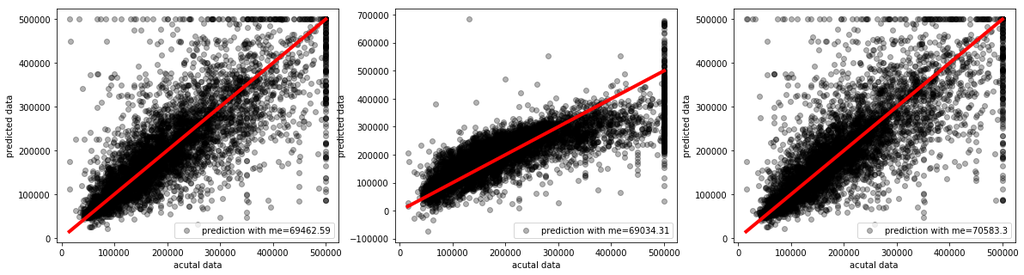

```python
plot_predictions_multi(
    models=[rf_model, lr_model, dt_model],
    X_test_processed=X_test_processed,
    y_test=y_test,
    y_pipeline=y_pipeline
)
```

## 6️⃣ Deployment

Deployment is the method by which you integrate a machine learning model into an existing production environment in order to start using it to make practical business decisions based on data. It is one of the last stages in the machine learning life cycle and can be one of the most cumbersome. Often, an organization’s IT systems are incompatible with traditional model-building languages, forcing data scientists and programmers to spend valuable time and brainpower rewriting them.

Hier haben wir euch einige Optionen aufgelistet, wie ein trainiertes ML Modell eingesetzt werden kann:

- **REST API**: Wer selbst einen Web-Server betreibt, kann sein/ihr MLM z.B. über eine REST Schnittstelle zugänglich machen. In diesem Fall wird das Modell am Server z.B. via Python + Flask gehostet, empfängt Eingaben in Form von HTTP Requests und macht seine Ergebnisse z.B. als JSON Response zugänglich.
- **Cloud Service**: Wer selbst keinen Web-Server betreibt oder mehr Power hinter sein/ihr MLM bekommen möchte (Stichwort Skalierung) kann mit seinem/ihrem Modell natürlich auch auf eine Cloud-Plattform (z.B. Amazon Web Servcies, Google Cloud, Microsoft Azure, usw.) ausweichen. Alle gängigen Plattformen bieten hier geeignete Lösungen an. Manche Produkte unterstützen sogar schon in den frühen Phasen des ML Prozess und bieten vollständige Pipelines an (z.B. [Microsoft in seinem Azure Machine Learning Studio](https://azure.microsoft.com/en-us/services/machine-learning-studio/)).
- **On-Premise Deployment**: Nicht immer müssen MLM online deployt werden. Oft genügt es, ein Modell auf einem einzelnen Endgerät verfügbar zu machen.

> **Noch ein Hinweis**:Ein MLM ist eine mathematische Struktur - im Fall eines Regressionsmodells etwa $y = \beta_0 + \beta_1x_1+\beta_2x_2+...+\beta_nx_n$. Daher ist es im Grunde egal, in welcher Sprache die Daten für das Training vorbereitet und das eigentliche Training durchgeführt wurde. Das fertige Modell lässt sich praktisch in jede Sprache (Java, JavaScript, php, C, C# usw.) auslagern; sieht man einmal vom Auslagerungsaufwand ab. Online-Learning stellt hier vielleicht als einzige ML-Strategie einen Sonderfall dar.

Wir stellen uns hier vor, dass wir unser MLM über einen Web-Server zur Verfügung stellen. Hier hilft uns z.B. die Python bibliothek `flask`. Da wir unser MLM hier in einem Jupyter Notebook entwickelt haben, müssen wir im ersten Schritt unser Modell serialisieren. Dazu verwenden wir `dill.dump()`.

```python
from dill import dump

output_file = "mlm_dumps/lr_model.pk"

# open the dedicated output file in write-binary mode
with open(output_file, "wb") as dump_file:
    dump(lr_model, dump_file)
```

Zusätzlich zum MLM müssen wir aber auch unsere gesamte Vorverarbeitungspipeline serialisieren - wir müssen schließlich alle neu herein kommenden Daten ebenso vorverarbeiten. Auch hier verwenden wir `dill.dump()`.

```python
output_file = "mlm_dumps/X_pipeline.pk"

# open the dedicated output file in write-binary mode
with open(output_file, "wb") as dump_file:
    dump(X_pipeline, dump_file)
```

```python
output_file = "mlm_dumps/y_pipeline.pk"

# open the dedicated output file in write-binary mode
with open(output_file, "wb") as dump_file:
    dump(y_pipeline, dump_file)
```

```
"""This skript deploys a simple flask Web server which serves a serialized MLM
:author: Michael Kohlegger
:date:
"""

import pandas as pd
from flask import Flask, request, render_template, jsonify
from dill import load
from numpy import array


input_file = "lr_model.pk"
with open(input_file, "rb") as input_file:
        lr_model = load(input_file)

input_file = "X_pipeline.pk"
with open(input_file, "rb") as input_file:
        X_pipeline = load(input_file)

input_file = "y_pipeline.pk"
with open(input_file, "rb") as input_file:
        y_pipeline = load(input_file)


def create_prediction(
    longitude,
    latitude,
    housing_median_age,
    total_rooms,
    total_bedrooms,
    population,
    households,
    median_income,
    dist_lt_1h_ocean,
    dist_inland,
    dist_island,
    dist_near_bay,
    dist_near_ocean
):
    """This method creates a prediction using a serialized machine learning model

    :param longitude: A measure of how far west a house is; a higher value is farther west
    :param latitude: A measure of how far north a house is; a higher value is farther north
    :param housing_median_age: Median age of a house within a block; a lower number is a newer building
    :param total_rooms: Total number of rooms within a block
    :param total_bedrooms: Total number of bedrooms within a block
    :param population: Total number of people residing within a block
    :param households: Total number of households, a group of people residing within a home unit, for a block
    :param median_income: Median income for households within a block of houses (measured in tens of thousands of US Dollars)
    :param dist_lt_1h_ocean: Distance measure; 1 if < 1h to the ocean.
    :param dist_inland: Distance measure; 1 if inland.
    :param dist_island: Distance measure; 1 if island.
    :param dist_near_bay: Distance measure; 1 if near bay.
    :param dist_near_ocean: Distance measure; 1 if near ocean.
    :return: Prediction as Float.
    """

    # Create data object
    data = [[
        longitude,
        latitude,
        housing_median_age,
        total_rooms,
        total_bedrooms,
        population,
        households,
        median_income,
        dist_lt_1h_ocean,
        dist_inland,
        dist_island,
        dist_near_bay,
        dist_near_ocean
    ]]

    # Scale data object
    data_pre = X_pipeline.transform(data)

    # Generate prediction
    # Inverse scale prediction to original
    prediction = y_pipeline.inverse_transform(
        lr_model.predict(data_pre)
    )[0][0]

    return prediction


# Define Flask web service
app = Flask(__name__)


# Display a short message when root is called
@app.route('/')
def home_call():
    return "This is a flask Web service."


@app.route('/predict', methods=['GET'])
def predict():
    """This method creates a prediction from a http request
    :
    """
    # Read request argurments with default = 0
    longitude = float(request.args.get('longitude', '0'))
    latitude = float(request.args.get('latitude', '0'))
    housing_median_age = float(request.args.get('housing_median_age', '0'))
    total_rooms = float(request.args.get('total_rooms', '0'))
    total_bedrooms = float(request.args.get('total_bedrooms', '0'))
    population = float(request.args.get('population', '0'))
    households = float(request.args.get('households', '0'))
    median_income = float(request.args.get('median_income', '0'))
    dist_lt_1h_ocean = float(request.args.get('dist_lt_1h_ocean', '0'))
    dist_inland = float(request.args.get('dist_inland', '0'))
    dist_island = float(request.args.get('dist_island', '0'))
    dist_near_bay = float(request.args.get('dist_near_bay', '0'))
    dist_near_ocean = float(request.args.get('dist_near_ocean', '0'))

    # Create a new prediction for the incoming data
    prediction = create_prediction(
        longitude,
        latitude,
        housing_median_age,
        total_rooms,
        total_bedrooms,
        population,
        households,
        median_income,
        dist_lt_1h_ocean,
        dist_inland,
        dist_island,
        dist_near_bay,
        dist_near_ocean
    )

    output_dictionary = {
        "output_value": prediction,
        "message": "You can expect a median house value of " + str(prediction) + ".",
        "input_values": {
            "longitude": longitude,
            "latitude": latitude,
            "housing_median_age": housing_median_age,
            "total_rooms": total_rooms,
            "total_bedrooms": total_bedrooms,
            "population": population,
            "households": households,
            "median_income": median_income,
            "dist_lt_1h_ocean": dist_lt_1h_ocean,
            "dist_inland": dist_inland,
            "dist_island": dist_island,
            "dist_near_bay": dist_near_bay,
            "dist_near_ocean": dist_near_ocean
        }
    }

    return jsonify(output_dictionary)


@app.route('/predict/form')
def form():
    return render_template("input.html", title="Median House Value")


# Run app if directly called
if __name__ == "__main__":
    app.run(host='localhost', port=9999, debug=True)
```